# Statistik och dataanalys I

F4: Jämföra fördelningar, tidsserier, och transformationer.

Valentin Zulj

## Vad har vi gjort hittills

Hittills har vi pratat om

- Fördelningar för kategoriska variabler (t.ex. stapeldiagram)
- Fördelningar för numeriska variabler (t.ex. histogram)
- Hur vi illustrera/presenterar samband mellan kategoriska variabler (t.ex. korstabeller)

## Vad vi ska göra idag

- Samband mellan en kategorisk och en numerisk variabel
  - Betinga numeriska variabler på kategoriska
  - Lådagram
  - Samband och slump
  - Spridningsdiagram
- Tidsserier
  - Säsongsvariation
  - Utjämning
- Transformationer

# Betinga numeriska variabler på kategoriska

## Repetition

- När vi intresserar oss för **kategoriska variabler** vill vi oftast veta hur stora olika grupper av observationer är
- När vi intresserar oss för **numeriska variabler** kan vi vilja undersöka
  - **centralmått** som medelvärde och median
  - **spridningsmått** som, standardavvikelse och kvartilavstånd (se F2)

## Numeriska variabler betingade på kategoriska

> - För att undersöka sambandet mellan en numerisk variabel och en kategorisk variabel kan vi studera fördelningen av den numeriska variabeln **betingat** på den kategoriska variabeln
> - Med **två kategoriska variabler** kan vi ställa frågor som:
>   - Är andelen BMW-förare som kör för fort större än motsvarande för Toyota-förare?
> - Med **en numerisk och en kategorisk variabel** kan vi ställa frågor som:
>   - Hur snabbt kör BMW-förare i genomsnitt på en viss vägsträcka?
>   - Som jämförelse, hur snabbt kör Toyota-förare i genomsnitt på samma vägsträcka?
> - Vi undersöker alltså hastigheten (numerisk variabel) betingat på bilmärket (kategorisk variabel)

## Illustration av betingad fördelning

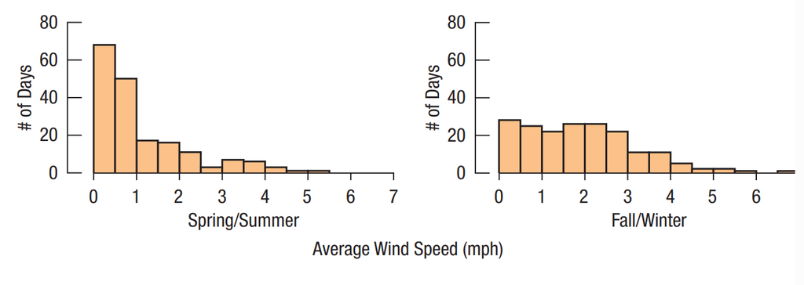

- Figur 4.2 i De Veaux et al. (2021) visar medelvindhastigheten separat för två säsonger: vår/sommar och höst/vinter
- Jämfört med fördelningen för hela året kan vi se att
  - Det blåser mindre under vår/sommar
  - Det är fler dagar med mycket vind under höst/vinter

## Illustration av betingad fördelning

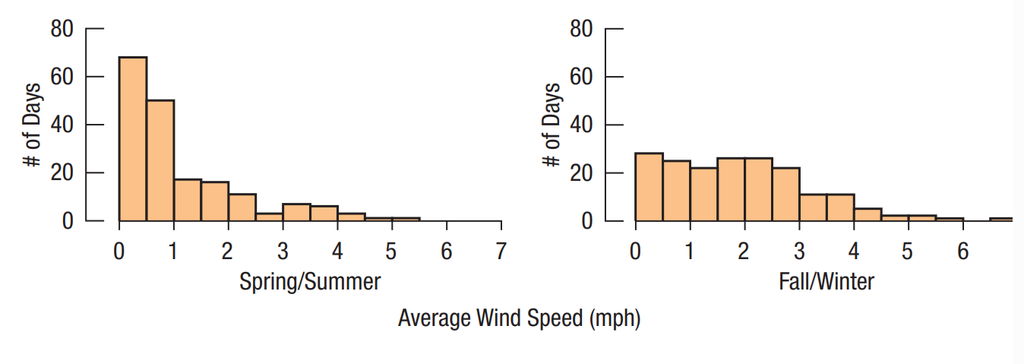

- Är vi intresserade av vindstyrkan under en viss tid på året ger de betingade fördelningarna en bättre bild än marginalfördelningen
- Från föreläsning 3: Marginalfördelningen är den fördelning av en variabel som inte tar hänsyn till andra variabler (t.ex årstid)

## Varför betinga numeriska variabler på kategoriska?

- Vi får en bättre bild av vindstyrkan om vi betingar variabeln på årstid
- Vi kan få en ännu bättre bild av vindstyrkan om vi bryter ned observationerna i 12 månadsgrupper istället för bara två säsonger
- Men hur ska vi illustrera de tolv månaderna? Tolv separata histogram blir svåröverskådligt
- Som ett alternativ till histogram kan vi använda **låddiagram** (*en: boxplot*)

## Låddiagram

- Medan histogrammet ger en mer komplett bild av fördelningen visar låddiagrammet ett antal nyckelmått:
  - Medianen
  - $Q_1$
  - $Q_3$
  - Kvartilavståndet
  - Värdet av den största och den minsta observationen

## Låddiagram - hur det är uppbyggt

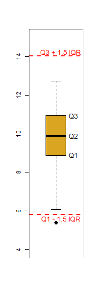

## Låddiagram - hur det är uppbyggt

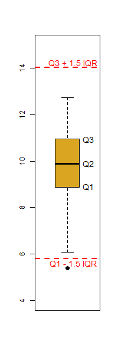

- **De röda stödlinjerna** är inte en del av diagrammet. De är placerade vid $Q1 - 1.5 \cdot IQR$ respektive $Q3 + 1.5 \cdot IQR$
- Observationer som ligger utanför stödlinjerna räknas som **outliers** och ritas ut som punkter
- I detta låddiagram har vi en sådan punkt under den nedre röda linjen
- Vi har inga outliers i den över delen av diagrammet.
- Diagrammet kan också vara liggande

## Låddiagram - tolkning

Vi använder det vi vet om låddiagram för att utläsa information om vindstyrkan i västra Massaschussets:

## Låddiagram - tolkning

Vi använder det vi vet om låddiagram för att utläsa information om vindstyrkan i västra Massaschussets:

## Jämföra fördelningar med låddiagram

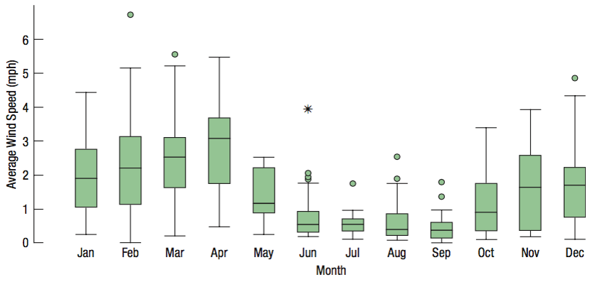

- Lådagram gör det enklare att jämföra flera olika fördelningar
- Figur 4.3 i De Veaux et al. (2021) visar vindstyrkorna betingade på månad
- Mönster: det blåser mindre under sommaren, med mindre variation
- Stjärnan över juni är en extrem outlier, som representerar en tornado

## Numeriska betingade fördelningar - samband och slump

- På föreläsning 3 tog vi upp frågan om **skillnader mellan grupper** i ett datamaterial
- Vi diskuterade hur vi kan bedöma om skillnaderna beror på slumpen eller på att det finns ett mer generellt samband
- Som exempel använde vi Titanics livbåtar, och tittade på hur livbåtsplatser fördelades mellan passagerare i olika klasser
- Till slut ställde vi upp **hypotesen** att livbåtsplatserna var slumpmässigt fördelade och oberoende av biljetklass, och expreimenterade lite
- Vi upprepade ett experiment där vi lät platserna i livbåtarna fördela sig slumpvis mellan alla passagerare, **som om vår hypotes var sann**

## Numeriska betingade fördelningar - samband och slump

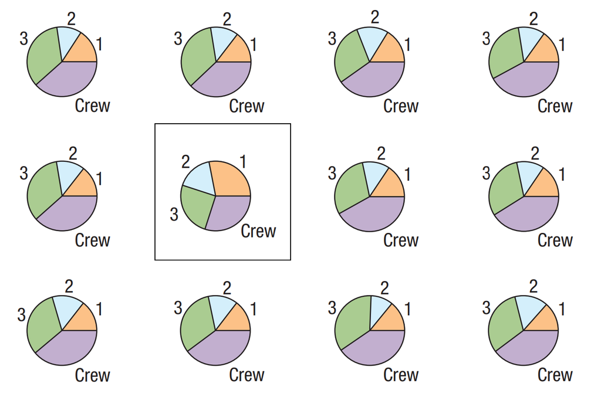

- För varje upprepning gjorde vi ett pajdiagram, och jämförde dessa diagram med den verkliga fördelningen
- Den verkliga fördelningen ser inte slumpmässig ut, och vi lutar så åt att det finns ett samband

## Numeriska betingade fördelningar - samband och slump

- Vi vill nu göra något liknande, men denna gång vill vi undersöka om **skillnaden mellan två numeriska fördelningar** beror på slumpen eller inte
- Vi antar att vi mäter hastigheten för bilar som kör längs en given gata, och fokuserar särskilt på BMW och Toyota
- Vi kan sedan illustrera de två hastighetsfördelningarna (en för BMW och en för Toyota) med två låddiagram

## Numeriska betingade fördelningar - samband och slump

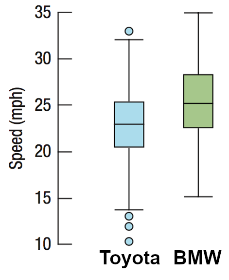

- Medelhastigheten hos de bilar som kör BMW är 2.53 mph högre än medelhastigheten hos de som kör Toyota.
- Betyder det att BMW-förare generellt kör snabbare än Toyota-förare, eller beror skillnaden i medelhastighet på slumpen?

## Numeriska betingade fördelningar - samband och slump

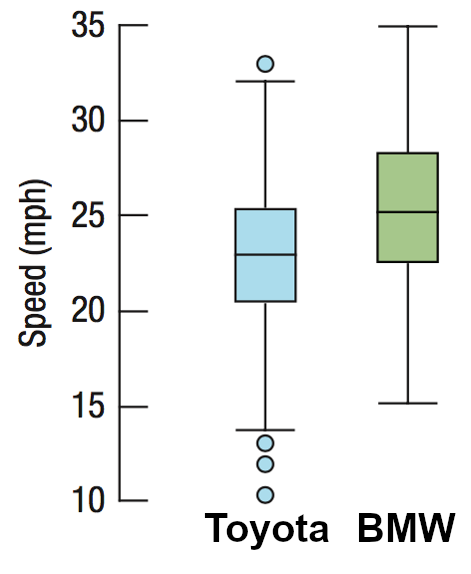

- Vi vill veta om skillnaden i medehastighet beror på på att de som kör det ena bilmärket generellt kör snabbare, eller skillnaden beror på slumpen
- Vi kan ställa upp **hypotesen** att hastigheten är oberoende av bilmärke
- Om hypotesen är sann var det enbart slumpen som gjorde så att BMW-förarna körde snabbare i just de fall vi mätte upp

## Numeriska betingade fördelningar - samband och slump

- **Vi gör ett tankeexperiment:** Anta att vi inte känner till vilket bilmärke som är kopplat till vilken hastighet i vår data
- Istället för att dela upp bilarna efter märke, delar vi slumpmässigt in dem slumpvis i två grupper som vi kallar A och B
- Eftersom indelningen är slumpmässig, kommer hastigheten nu att vara oberoende av vilken grupp bilarna hamnar i
- Efter att varje bil, som har en viss hastighet, slumpvis har placerats i en grupp räknar vi ut medelhastigheten för vardera grupp
- Vi noterar skillnaden i medelhastighet mellan de två grupperna (Medelvärdet för grupp A minus medelväldet för grupp B).

## Numeriska betingade fördelningar - samband och slump

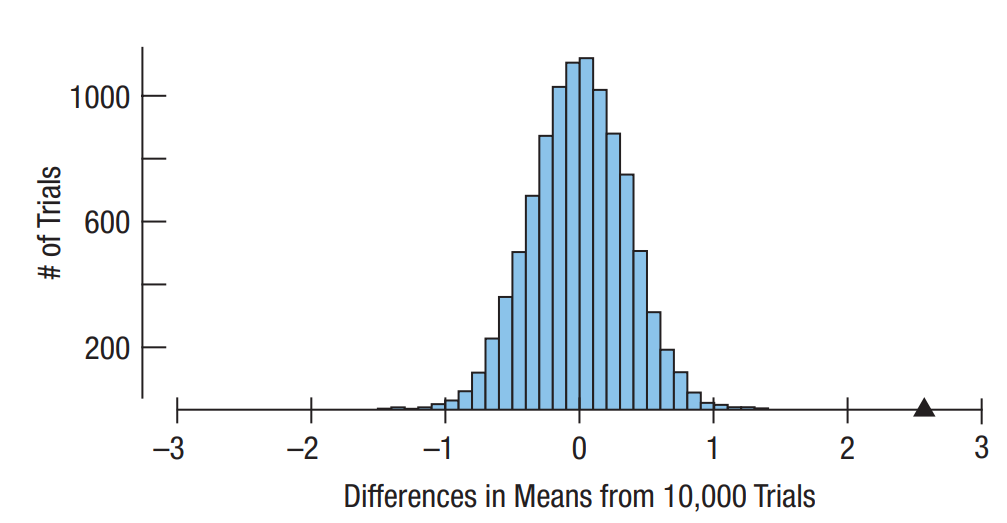

- Nu upprepar vi detta slumpexperiment **ett stort antal**
- Figur 4.5 i De Veaux et al. (2021) visar utfallet av 10,000 sådana experiment
- Skillnaden som uppmättes i studien (2.53 mph) är markerad med en triangel
- Vilka slutsatser kan vi dra?

## Numeriska betingade fördelningar - samband och slump

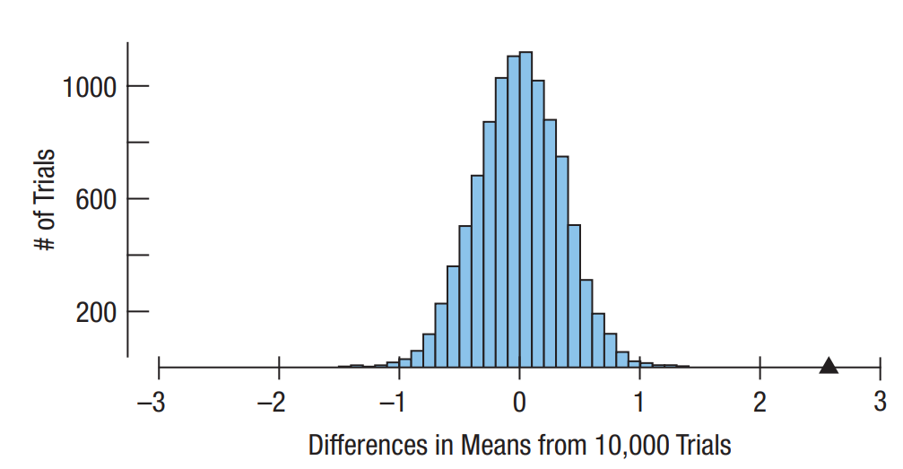

- Triangeln ligger långt till höger om vad som rimligtvis skulle kunna förväntas om skillnaden bara berodde på slumpen
- Skillnaden är mycket större än vad som vore rimligt om slumpen styrde
- Vi lutar alltså åt att BMW-förare faktiskt kör snabbare

## Spridningsdiagram (scatter plot)

# Tidsserier

## Tidsserieplot

- Vi binder gärna samman punkterna för att lättare urskilja mönster
- Vanligtvis är vi intresserade av att titta efter
  - Trender
  - Säsongsvariation
- Trender och säsongsvariationer kan vara viktiga om du vill göra prognoser

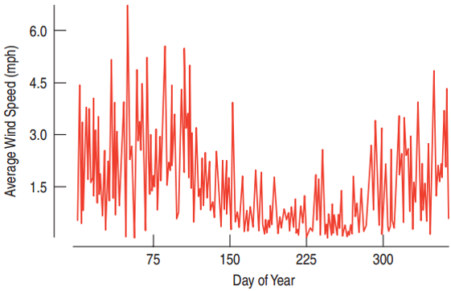

## Trender

- **En trend** är en kontinuerlig förändring som sker över tid
- Grafen nedan visar Sveriges bruttonationalprodukt från 1960 till 2020
- Även om BNP sjunker vissa år är trenden positiv – om vi drog en rak linje från 1960 till 2020 skulle linjen peka kraftigt uppåt

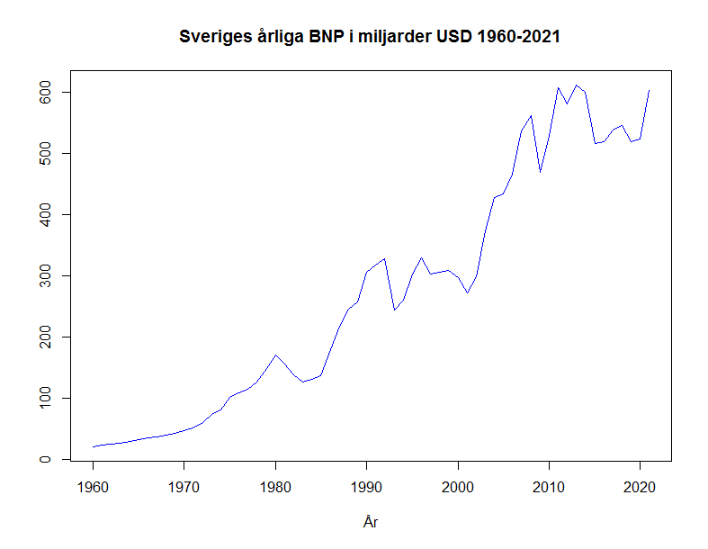

## Säsongsvariation

- **säsongsvariation** är ett mönster som upprepar sig över tydligt avgränsade tidsperioder (vanligtvis år)
- Säsongsvariation syns ofta i exempelvis tidsserier över väder och försäljning (i regel högre temperaturer på sommaren och lägre på vintern, etc)
- Bilden ned visar temperaturer insamlade mellan 1 februari 2008 och 1 maj 2022 vid tre svenska flygplatser (Bild från Villani et al. (2022))

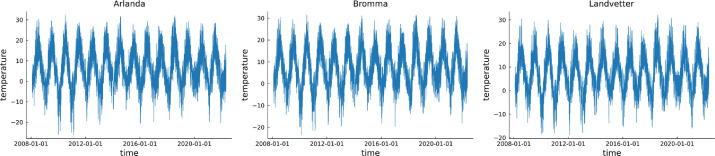

## Utjämning (smoothing)

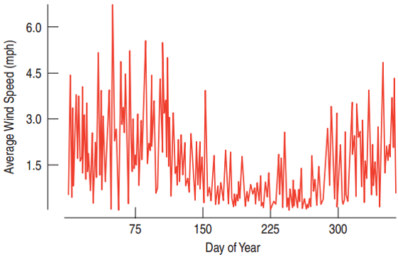

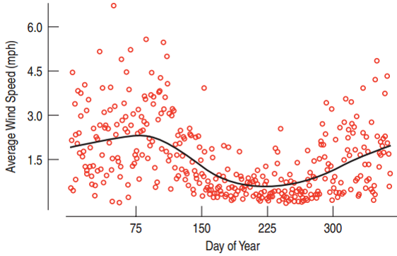

# Transformationer

## Varför transformera?

- Vi motiverar **transformation** av variabler med hjälp av en forskningsstudie
- Studien undersöker om exponering för rökning påverkade nivån av kotinin i blodet (nedbrytningsprodukt av nikotin)
- Deltagarna i studien delades in i tre grupper:
  - Rökare (Smoker)
  - Passiva rökare (ETS, *exposed to smoke*)
  - De som inte utsattes för någon rök (No ETS)
- Vi har alltså en kategorisk variabel (grupptillhörighet) och en numerisk variabel (mängd kotonin i blodet, nanogram/ml)

## Transformationer

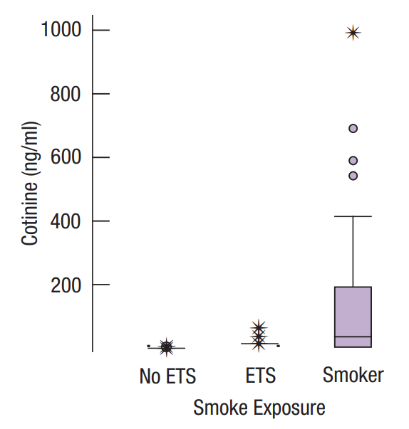

- I figuren finns tre låddiagram, där varje diagram visar fördelningen av kotonin-nivå i respektive grupp
- Ser vi några problem med diagrammet?

## Transformationer

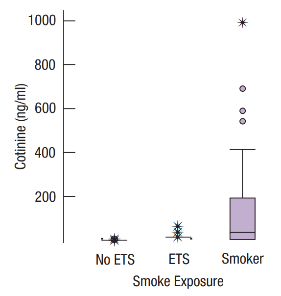

- När värden är ojämnt fördelade kan det svara svårt att läsa ett diagram – i detta fall är en stor del värdena ihopklämda i botten av diagrammet
- Det är omöjligt att se skillnaden mellan passiva rökare (ETS) och de som inte exponerats för rök (No ETS)

## Transformationer

- Med hjälp av en transformation kan vi göra diagrammen mer lättläsliga, i detta fall kan vi transformera y-axeln från kotinin till log(kotinin)

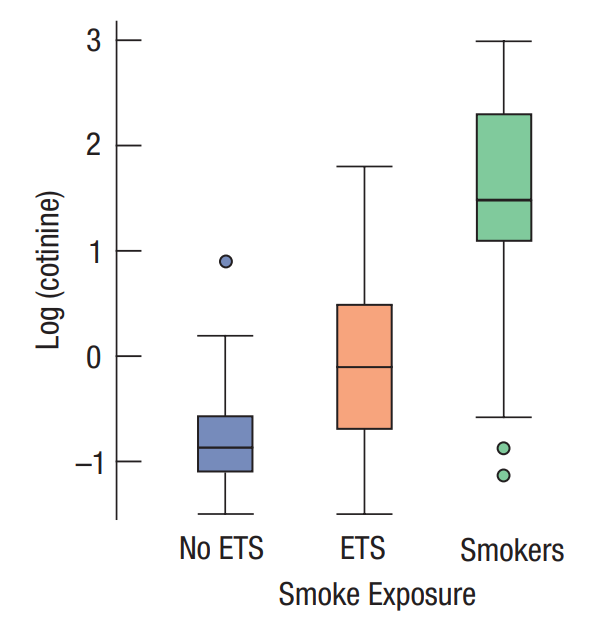

- Vi ser nu tydligt att de som exponerats för rök har högre halter av kotinin
- Men: nu har vi **log(kotinin)** på y-axeln, och **inte** mängden kotinin

## Logaritmer

- Följande samband är bra att känna till för att kunna översätta mellan logaritmer och vår ursprungliga skala:

$$y = e^x \Longleftrightarrow \log(y) = x$$

- Vi kan också skriva

$$y = e^{log(y)}$$
- Uttrycket $e$ är en konstant med ett värde som är ungefär 2.7.

- **Exempel:** Antag att vi vet att $\log(a) = 1.2$, och att vi vill hitta värdet på $a$
- Vi vet då att $a = e^{\log(a)}$, vilket innebär att

$$a = e^{\log(a)} = e^{1.2} = 3.32$$

## Transformationer i R

- Vi skapar en variabel som vi kallar $y$, med värden som skiljer sig kraftigt i storleksordning, och försöker illustrera $y$ med ett låddiagram

```r
y <- c(0.2, 0.3, 2, 3,  5, 700, 14000) #Skapa en vektor
bwplot(y) # Gör en boxplot av y med mosaic-paketet
```

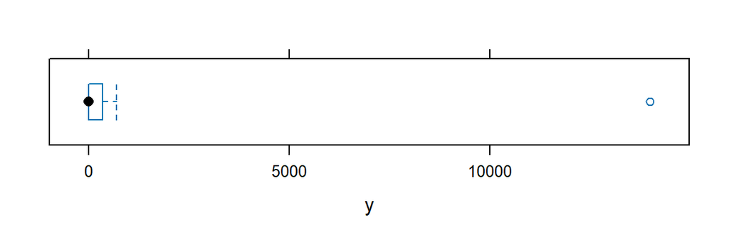

- Resultatet blir ett låddiagram som är svårt att läsa, då nästan alla observationer är ihoptryckta i diagrammets vänstra del

## Transformationer i R

- Vi skapar nu variabeln $\log y$, som är logaritmen av $y$, och skriver ut den nya variabelns värden avrundade till 3 decimaler

```r
logy <- log(y)
print(round(logy, 3)) # Skriv ut den logaritmerade vektorn,
```

```
[1] -1.609 -1.204  0.693  1.099  1.609  6.551  9.547
```

- Trots att våra ursprungliga värden varierar stort, från 0.2 till 14 000, håller sig våra logaritmerade värden inom ett intervall från ungefär -1.6 till 9.5

## Transformationer i R

- Vi sammanfattar våra värden i $\text{logy}$ med ett låddiagram

```r
bwplot(logy) # Gör en boxplot av y med mosaic-paketet
```

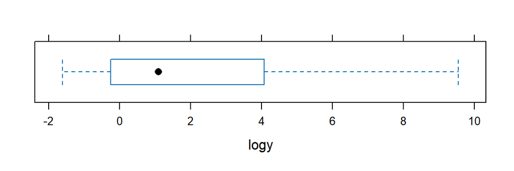

- Resultatet blir ett låddiagram som är mer lättläst

## Transformationer i R

- Vi kan transformera tillbaka våra värden till orginalskalan med formeln
  $$y = e^{\log{(y)}}, \; \text{ där } \; e \approx 2.718$$

```r
y_backtransformed <- exp(logy) # Transformera tillbaka
y_backtransformed # Skriv ut y
```

```
[1]     0.2     0.3     2.0     3.0     5.0   700.0 14000.0
```

- Vi ser att de värden som transformerats tillbaka är våra ursprungliga värden
- Notera att $e^x$ i R skrivs `exp(x)`

## Transformationer

- Logaritmering är användbart i otroligt många statistiska tillämpningar
- Men det är bara en av många transformationer som vi kan ha nytta av
- När vi kommer till avsnittet om regression kommer transformering att spela en större roll
- Om du tycker att transformationer verkar jobbigt, oroa dig inte!
- På den här kursen kommer transformationer inte handla om matematik, utan mer om att pröva sig fram

## Credits

Dessa slides skapades av Karl Sigfrid för kursen Statistik och Dataanalys I och har uppdaterats av Oskar Gustafsson och Valentin Zulj